# CSCIE89 HW05 – Problem 4: Grad-CAM on the Problem 3 VGG16 flower model

**Goal:** use **Grad-CAM** (class-discriminative heat map for a single target convolutional layer) from Lab notebook **02_lab5_TL-resnet_xception** to see which parts of a flower image the **Problem 3 stage 2 model** used for its prediction.

**How this notebook is organised:**

1. **Sections 1–8 – rebuild the Problem 3 stage 2 model.** Problem 3 did not save the trained model, so these sections re-run the Problem 3 code unchanged (same data split, seed and settings) to recreate it.
2. **Section 9 – Grad-CAM tools**, copied from the lab notebook: `denormalize`, the `GradCAM` class and `show_gradcam`.
3. **Section 10 – apply Grad-CAM** to flower test images.
4. **Section 11 – report** on what the heat maps show.

**Target layer:** `conv_base[28]`, the **last convolutional layer of VGG16** (block 5, conv 3). It is the VGG16 counterpart of the lab's `resnet_model.layer4` and `xception_model.conv4`: the final, most class-specific feature maps before pooling and the classifier. It is also one of the layers fine-tuned in stage 2.

## 1. Import tools and choose training settings

Same as Problem 3, section 1.

```python
# Run once if packages are missing, then restart the kernel:
# %pip install torch torchvision scikit-learn matplotlib pillow

from pathlib import Path                                             # Tool for building folder/file paths.
import copy                                                          # Lets us save an independent copy of the model's weights.
import torch                                                         # PyTorch: the deep-learning library.
from torch import nn                                                 # Building blocks for networks (layers, loss functions).
from torch.utils.data import DataLoader, Subset                      # DataLoader feeds images in batches; Subset picks some images by their index.
from torchvision import datasets, models, transforms                 # Image-folder reader, pretrained models (VGG16), image resizing/augmenting.
from torchvision.datasets.utils import download_and_extract_archive  # Downloads a zip/tgz file and unpacks it.
from sklearn.model_selection import train_test_split                 # Splits data into train/validation/test.
from sklearn.metrics import classification_report, precision_score   # Precision/recall table, and overall precision.
import matplotlib.pyplot as plt                                      # For showing images.
from PIL import Image                                                # For opening image files.

SEED = 42                                        # Fixed random seed, so we get the same data split.
IMAGE_SIZE = 150                                 # Every photo is resized to 150 x 150 pixels.
BATCH_SIZE = 20                                  # The model looks at 20 photos at a time.
INITIAL_EPOCHS = 5                               # Stage 1: up to 5 passes over the training photos.
FINETUNE_EPOCHS = 3                              # Stage 2: up to 3 more passes.
INITIAL_LR = 2e-5                                # Stage 1 learning rate (size of each weight update).
FINETUNE_LR = 1e-5                               # Stage 2 learning rate: smaller, so VGG16's weights change gently.
PATIENCE = 3                                     # Stop a stage early if validation loss doesn't improve for 3 epochs.

torch.manual_seed(SEED)                                                        # Make PyTorch's random choices repeatable.
torch.set_num_threads(4)                                                       # Limit CPU threads (only matters when there is no GPU).
device = torch.device('cuda' if torch.cuda.is_available() else                 # Use the NVIDIA GPU if there is one (Colab),
                      'mps' if torch.backends.mps.is_available() else 'cpu')   # else an Apple GPU, else the CPU.
print('Using device:', device)                                                 # Show which one we are using.
```

```
Using device: cuda
```

## 2. Google Drive + local Colab setup: load the flower images

Same as Problem 3, section 2.

```python
# GOOGLE DRIVE + LOCAL COLAB SETUP

from google.colab import drive                   # Colab tool to connect your Google Drive.
import shutil                                    # For copying whole folders.

drive.mount('/content/drive')                    # Connect Google Drive (asks for permission the first time).

# Permanent location in Google Drive
PROJECT_DIR = Path('/content/drive/MyDrive/CSCI-E-89-1-Deep-Learning/HW05')  # homework folder in Drive.
DRIVE_DATA_DIR = PROJECT_DIR / 'data'                                       # Data folder in Drive.
DRIVE_DATA_DIR.mkdir(parents=True, exist_ok=True)                           # Create it if it doesn't exist yet.

# IMPORTANT: # DATA_DIR is the fast temporary Colab drive

DATA_DIR = Path('/content/data')                                            # Colab's own disk: fast, but erased when the session ends.
DATA_DIR.mkdir(parents=True, exist_ok=True)                                 # Create it if it doesn't exist yet.


flower_root = DATA_DIR / 'flower_photos'                                    # Where training reads the flowers from (fast disk).
drive_flower_root = DRIVE_DATA_DIR / 'flower_photos'                        # Where the permanent copy lives (Drive).

# If flowers are not already in Colab
if not flower_root.exists():

    # Copy from Google Drive if already saved there
    if drive_flower_root.exists():
        shutil.copytree(drive_flower_root, flower_root)  # Copy Drive -> Colab disk (faster than downloading).

    # Otherwise download them into Colab
    else:
        download_and_extract_archive(            # Download the flower archive and unpack it:
            'https://storage.googleapis.com/download.tensorflow.org/example_images/flower_photos.tgz',  # from this web address,
            download_root=str(DATA_DIR),         # into the Colab disk.
        )

# Save a permanent copy to Google Drive if one does not exist
if not drive_flower_root.exists():
    shutil.copytree(flower_root, drive_flower_root)  # Copy Colab disk -> Drive (happens only the first time).

print('Flower directory:', flower_root)          # Show where the photos are.
```

```
Flower directory: /content/data/flower_photos
```

## 3. Prepare images for VGG16

Same as Problem 3, section 3.

```python
MEAN = [0.485, 0.456, 0.406]                     # Average red, green, blue values of ImageNet photos.
STD = [0.229, 0.224, 0.225]                      # Spread of red, green, blue values of ImageNet photos.

train_transform = transforms.Compose([           # Steps applied to each TRAINING photo, in order:
    transforms.Resize((IMAGE_SIZE, IMAGE_SIZE)), # 1. Resize to 150 x 150.
    transforms.RandomHorizontalFlip(),           # 2. Mirror left-right, at random (half the time).
    transforms.RandomRotation(10),               # 3. Turn by a random angle between -10 and +10 degrees.
    transforms.ToTensor(),                       # 4. Turn the picture into numbers between 0 and 1.
    transforms.Normalize(MEAN, STD),             # 5. Rescale those numbers the same way VGG16 saw ImageNet photos.
])

eval_transform = transforms.Compose([            # Steps applied to VALIDATION and TEST photos (no random changes):
    transforms.Resize((IMAGE_SIZE, IMAGE_SIZE)), # 1. Resize to 150 x 150.
    transforms.ToTensor(),                       # 2. Turn the picture into numbers between 0 and 1.
    transforms.Normalize(MEAN, STD),             # 3. Rescale like ImageNet.
])

# ImageFolder assigns integer labels using alphabetically sorted folder names.
train_view = datasets.ImageFolder(flower_root, transform=train_transform)           # All 3,670 flowers, read with the TRAINING steps.
eval_view = datasets.ImageFolder(flower_root, transform=eval_transform)             # The same 3,670 flowers, read with the TEST steps.
class_names = train_view.classes                                                    # The 5 class names (folder names), in label order.
num_classes = len(class_names)                                                      # 5.
assert train_view.class_to_idx == eval_view.class_to_idx                            # Safety check: both views give each class the same number.
print('Class mapping:', train_view.class_to_idx)                                    # daisy=0, dandelion=1, roses=2, sunflowers=3, tulips=4
```

```
Class mapping: {'daisy': 0, 'dandelion': 1, 'roses': 2, 'sunflowers': 3, 'tulips': 4}
```

## 4. Separate training, validation, and test data

Same as Problem 3, section 4 (2,569 / 550 / 551 images).

```python
all_indices = list(range(len(eval_view)))                                          # Number every photo: 0, 1, 2, ..., 3669.
train_indices, remaining = train_test_split(                                       # Split 1: put 70% of the photo numbers in training, keep 30% aside.
    all_indices, test_size=0.30,                                                   # All photo numbers; 30% go to the 'aside' part.
    random_state=SEED, stratify=eval_view.targets,                                 # Same split every run; each part keeps the same mix of flower types.
)
val_indices, test_indices = train_test_split(                                      # Split 2: cut the 30% in half -> 15% validation, 15% test.
    remaining, test_size=0.50,                                                     # The 30% set aside; half of it goes to test.
    random_state=SEED, stratify=[eval_view.targets[i] for i in remaining],         # Again keep the same mix of flower types.
)

train_data = Subset(train_view, train_indices)                                     # Training photos (with random flips/rotations).
val_data = Subset(eval_view, val_indices)                                          # Validation photos (no random changes).
test_data = Subset(eval_view, test_indices)                                        # Test photos (no random changes).
train_loader = DataLoader(train_data, batch_size=BATCH_SIZE, shuffle=True, num_workers=0)            # Training photos in batches of 20, new random order each epoch.
val_loader = DataLoader(val_data, batch_size=BATCH_SIZE, num_workers=0)                              # Validation photos in batches of 20.
test_loader = DataLoader(test_data, batch_size=BATCH_SIZE, num_workers=0)                            # Test photos in batches of 20 (all 551 of them).

print('Training:', len(train_data), '| Validation:', len(val_data), '| Test:', len(test_data))       # 2569 | 550 | 551
images, labels = next(iter(train_loader))                                                            # Grab one batch to check its shape.
print('One batch:', images.shape, '| Labels:', labels.shape)                                         # [20 photos, 3 colors, 150, 150] and 20 labels.
```

```
Training: 2569 | Validation: 550 | Test: 551
One batch: torch.Size([20, 3, 150, 150]) | Labels: torch.Size([20])
```

## 5. Reuse VGG16 features and add our classifier

Same as Problem 3, section 5.

```python
pretrained = models.vgg16(weights=models.VGG16_Weights.DEFAULT)  # Download VGG16, already trained on ImageNet.
conv_base = pretrained.features                  # Keep only its convolution layers (the part that recognises patterns).
del pretrained  # Release the large original classifier that we do not need.

# Freeze all pretrained convolution weights for stage 1.
for parameter in conv_base.parameters():         # For every weight in VGG16's convolution layers:
    parameter.requires_grad = False              # freeze it (it is used, but training will not change it).

with torch.no_grad():                            # Quick test run, no training:
    feature_shape = conv_base(torch.zeros(1, 3, IMAGE_SIZE, IMAGE_SIZE)).shape  # pass one blank image to see VGG16's output size.
    # Count the values from one image after flattening.
    number_of_features = feature_shape[1] * feature_shape[2] * feature_shape[3]  # 512 x 4 x 4 = 8,192 numbers per image.

model = nn.Sequential(                           # The full model, applied in this order:
    conv_base,                                   # 1. VGG16 turns the photo into 512 x 4 x 4 pattern scores.
    nn.Flatten(),                                # 2. Line them up into one list of 8,192 numbers.
    nn.Linear(number_of_features, 256),          # 3. New layer: 8,192 numbers -> 256 numbers.
    nn.ReLU(),                                   # 4. Set negative values to 0.
    nn.Dropout(0.5),                             # 5. During training, randomly switch off half of the 256 (reduces overfitting).
    nn.Linear(256, num_classes),                 # 6. New layer: 256 -> 5 scores, one per flower class (highest score = prediction).
).to(device)                                     # Put the model on the GPU (or CPU).
loss_function = nn.CrossEntropyLoss()            # Measures how wrong the 5 scores are vs. the true class (used for 3+ classes).
print('Convolution output:', tuple(feature_shape))  # (1, 512, 4, 4)
print('Flattened features:', number_of_features)    # 8192
print('Total parameters:', sum(p.numel() for p in model.parameters()))                          # All weights in the model.
print('Trainable parameters:', sum(p.numel() for p in model.parameters() if p.requires_grad))   # Weights that will learn (only the 2 new layers).
```

```
Convolution output: (1, 512, 4, 4)
Flattened features: 8192
Total parameters: 16813381
Trainable parameters: 2098693
```

## 6. Define one pass through the data, and the training loop

Same as Problem 3, sections 6 and 7.

```python
def run_epoch(loader, optimizer=None):                              # Go through all photos in `loader` once. With an optimizer it trains; without, it only measures.
    training = optimizer is not None                                # True = training pass, False = validation/test pass.
    model.train(training)                                           # Training mode turns Dropout on; evaluation mode turns it off.
    total_loss, correct, count = 0.0, 0, 0                          # Running totals, start at zero.
    # Gradients are needed for training but not for validation or testing.
    with torch.set_grad_enabled(training):
        for images, labels in loader:                               # Take one batch of 20 photos at a time:
            images = images.to(device)                              # put the photos on the GPU,
            labels = labels.to(device)                              # and their true classes (numbers 0-4).
            if training:                                            # Only when training:
                optimizer.zero_grad()                               # clear the previous batch's weight adjustments.
            logits = model(images)                                  # Model gives 5 scores per photo.
            loss = loss_function(logits, labels)                    # How wrong were the scores? (one number for the batch)
            if training:                                            # Only when training:
                loss.backward()                                     # work out how each weight should change,
                optimizer.step()                                    # and change the weights a little.
            total_loss += loss.item() * len(labels)                 # Add up the loss (times batch size, so the last smaller batch counts correctly).
            correct += (logits.argmax(1) == labels).sum().item()    # Count photos where the highest score is the true class.
            count += len(labels)                                    # Count photos seen.
    return total_loss / count, correct / count                      # Average loss and accuracy over all photos.
```

```python
def fit(epochs, learning_rate, stage_name):                                               # Train for up to `epochs` epochs and keep the best version of the model.
    # Create a new optimizer after changing which parameters are frozen.
    optimizer = torch.optim.RMSprop(                                                      # The optimizer is what updates the weights.
        [p for p in model.parameters() if p.requires_grad], lr=learning_rate,             # Give it only the unfrozen weights.
        alpha=0.9, eps=1e-7,                                                              # Technical settings of RMSprop.
    )
    history = {'train_loss': [], 'val_loss': [], 'train_accuracy': [], 'val_accuracy': []}  # Lists to record each epoch's results.

    # Evaluate the incoming model before changing any weights.
    best_loss, _ = run_epoch(val_loader)                                                  # Validation loss BEFORE this stage's training (the score to beat).
    best_weights = copy.deepcopy(model.state_dict())                                      # Save the starting weights as the best so far.
    best_epoch, waiting = 0, 0                                                            # Best epoch so far (0 = starting weights); epochs since last improvement.

    for epoch in range(1, epochs + 1):                                                    # For each epoch:
        train_loss, train_accuracy = run_epoch(train_loader, optimizer)                   # 1. Train on all training photos.
        val_loss, val_accuracy = run_epoch(val_loader)                                    # 2. Measure on the validation photos (no learning).
        history['train_loss'].append(train_loss)                                          # 3. Record this epoch's training loss,
        history['val_loss'].append(val_loss)                                              #    validation loss,
        history['train_accuracy'].append(train_accuracy)                                  #    training accuracy,
        history['val_accuracy'].append(val_accuracy)                                      #    and validation accuracy.

        # Select weights using validation loss, never test results.
        if val_loss < best_loss:                                                          # 4. If validation loss is the best so far:
            best_loss = val_loss                                                          #    remember it,
            best_weights = copy.deepcopy(model.state_dict())                              #    save a copy of these weights,
            best_epoch, waiting = epoch, 0                                                #    and reset the waiting counter.
        else:                                                                             #    Otherwise:
            waiting += 1                                                                  #    one more epoch without improvement.

        print(f'{stage_name} {epoch}/{epochs} | Train: {train_accuracy:.2%}'              # 5. Show progress: training accuracy,
              f' | Validation: {val_accuracy:.2%} | Val loss: {val_loss:.4f}', flush=True) #    validation accuracy and validation loss.
        if waiting >= PATIENCE:                                                           # 6. No improvement for 3 epochs in a row:
            print('Early stopping: validation loss stopped improving.')                    #    say so,
            break                                                                          #    stop this stage early.

    # Undo any later epochs that performed worse on validation data.
    model.load_state_dict(best_weights)                                                     # Go back to the best weights found.
    print(f'{stage_name}: restored best weights from epoch {best_epoch}.')                  # Say which epoch's weights are kept.
    return history                                                                          # Give back the recorded results.
```

## 7. Stage 1 — train only the new classifier

Same as Problem 3, section 8.

```python
history_initial = fit(INITIAL_EPOCHS, INITIAL_LR, 'Frozen base')  # Stage 1: VGG16 frozen, only the 2 new layers learn.
initial_val_loss, initial_val_accuracy = run_epoch(val_loader)    # Validation score of the best stage-1 model.
print(f'Selected stage-1 validation accuracy: {initial_val_accuracy:.2%}') # Show it.
```

```
Frozen base 1/5 | Train: 57.65% | Validation: 71.64% | Val loss: 0.8830
Frozen base 2/5 | Train: 75.79% | Validation: 75.45% | Val loss: 0.6807
Frozen base 3/5 | Train: 79.41% | Validation: 78.00% | Val loss: 0.5990
Frozen base 4/5 | Train: 82.17% | Validation: 81.27% | Val loss: 0.5498
Frozen base 5/5 | Train: 84.55% | Validation: 81.45% | Val loss: 0.5327
Frozen base: restored best weights from epoch 5.
Selected stage-1 validation accuracy: 81.45%
```

## 8. Stage 2 — fine-tune block 5 (this is the model we inspect)

Same as Problem 3, section 9. **Added:** a quick test-set check, to confirm the recreated model matches Problem 3 (90.38% test accuracy there; small differences can occur because GPU training is not perfectly repeatable).

```python
# Module index 24 starts block 5 (it is not the 24th convolution).
for parameter in conv_base[24:].parameters():                             # For every weight in VGG16's last block (block 5):
    parameter.requires_grad = True                                        # unfreeze it so it can learn. Blocks 1-4 stay frozen.

print('Trainable convolution modules:')                                   # Heading for the list below.
for index, layer in enumerate(conv_base):                                 # Go through VGG16's layers
    if isinstance(layer, nn.Conv2d) and layer.weight.requires_grad:       # and list the convolution layers that can now learn
        print(f'  features[{index}]: {layer}')                            # (should be the 3 in block 5).
print('Total trainable parameters:', sum(p.numel() for p in model.parameters() if p.requires_grad))  # Now block 5 + the 2 new layers.

history_finetune = fit(FINETUNE_EPOCHS, FINETUNE_LR, 'Fine-tuning')  # Stage 2: continue training, starting from the stage-1 model.
final_val_loss, final_val_accuracy = run_epoch(val_loader)           # Validation score of the best stage-2 model.
print(f'Selected final validation accuracy: {final_val_accuracy:.2%}') # Show it.
test_loss, test_accuracy = run_epoch(test_loader)                    # Check: test accuracy of the recreated stage-2 model
print(f'Stage 2 test accuracy: {test_accuracy:.2%} (Problem 3: 90.38%)') # should be close to Problem 3's result.
```

```
Trainable convolution modules:
  features[24]: Conv2d(512, 512, kernel_size=(3, 3), stride=(1, 1), padding=(1, 1))
  features[26]: Conv2d(512, 512, kernel_size=(3, 3), stride=(1, 1), padding=(1, 1))
  features[28]: Conv2d(512, 512, kernel_size=(3, 3), stride=(1, 1), padding=(1, 1))
Total trainable parameters: 9178117
Fine-tuning 1/3 | Train: 86.41% | Validation: 84.55% | Val loss: 0.4495
Fine-tuning 2/3 | Train: 89.84% | Validation: 83.09% | Val loss: 0.4451
Fine-tuning 3/3 | Train: 90.27% | Validation: 85.82% | Val loss: 0.4124
Fine-tuning: restored best weights from epoch 3.
Selected final validation accuracy: 85.82%
Stage 2 test accuracy: 90.38% (Problem 3: 90.38%)
```

## 9. Grad-CAM tools (from the lab notebook)

The three pieces below are the lab notebook's code, adapted to this model (`DEVICE` → `device`, `CLASS_NAMES` → `class_names`, cats/dogs → 5 flower classes):

- **`denormalize`** undoes the ImageNet normalization so the image can be displayed with its real colors.
- **`GradCAM`** attaches two **hooks** to the target layer:
  - a *forward hook* saves the layer's output (**activations**, one 2-D map per channel);
  - a *backward hook* saves the **gradients** of the chosen class score with respect to those activations.

  Then: average each channel's gradients → one **weight per channel** (how much that channel supports the class) → weighted sum of the activation maps → keep only positive evidence (ReLU) → resize to the image size → scale to 0–1.
- **`show_gradcam`** plots the input image, the heat map, and the heat map laid over the image.

**One change needed for VGG16:** VGG16's ReLU layers work *in place* (`inplace=True`), overwriting the conv layer's output. PyTorch's backward hook does not allow that, so we switch them to `inplace=False`, which writes the result into a new tensor. This changes memory use only; the model's outputs stay exactly the same.

```python
# ============================================================
# Undo ImageNet normalization for plotting
# ============================================================

def denormalize(image):                                     # Normalized image tensor -> displayable image.
    """
    Reverse ImageNet normalization for plotting.
    """
    mean = torch.tensor(MEAN, dtype=image.dtype).view(3, 1, 1)  # Channel means as a 3x1x1 tensor.
    std = torch.tensor(STD, dtype=image.dtype).view(3, 1, 1)    # Channel standard deviations as 3x1x1.
    return (image.detach().cpu() * std + mean).clamp(0, 1)      # x * std + mean, kept within 0..1.


# ============================================================
# Grad-CAM: class-discriminative heat-map visualization
# ============================================================

class GradCAM:
    """
    Grad-CAM for a single target convolutional layer.

    The heat map emphasizes locations whose activation channels,
    weighted by gradients, positively support a selected class logit.
    """

    def __init__(self, model, target_layer):               # Attach hooks to the target layer.
        self.model = model                                  # The trained network.
        self.activations = None                             # Will hold the layer's output maps.
        self.gradients = None                               # Will hold the gradients of those maps.

        self.forward_handle = (
            target_layer.register_forward_hook(self._save_activations)       # Save output on the forward pass.
        )

        self.backward_handle = (
            target_layer.register_full_backward_hook(self._save_gradients)   # Save gradients on the backward pass.
        )

    def _save_activations(self, module, inputs, output):    # Called automatically during the forward pass.
        self.activations = output                           # Layer output: [1, channels, height, width].

    def _save_gradients(self, module, grad_input, grad_output):  # Called automatically during the backward pass.
        self.gradients = grad_output[0]                     # Gradient of the class score w.r.t. that output.

    def generate(self, image, target_class=None):           # Build the heat map for one image.
        """
        Return:
            cam: normalized 2D heat map
            predicted_class: model prediction
            probabilities: flower-class softmax probabilities

        If target_class is None, use the predicted class.
        """

        self.model.eval()                                   # Evaluation mode (Dropout off).

        image_batch = image.unsqueeze(0).to(device)         # Add batch dimension: [1, 3, 150, 150].

        self.model.zero_grad(set_to_none=True)              # Clear old gradients.

        logits = self.model(image_batch)                    # Forward pass: 5 class scores (hook saves activations).

        predicted_class = int(logits.argmax(dim=1).item())  # Class with the highest score.

        if target_class is None:                            # No class chosen:
            target_class = predicted_class                  # explain the predicted class.

        # Differentiate the selected class score with respect
        # to the target layer's output activations.
        logits[0, target_class].backward()                  # Backward pass (hook saves gradients).

        # Spatially average gradients to get one weight per channel.
        channel_weights = self.gradients.mean(dim=(2, 3), keepdim=True)   # [1, 512, 1, 1]: importance of each channel.

        # Weighted activation sum, retaining only positive evidence.
        cam = torch.relu((channel_weights * self.activations).sum(dim=1, keepdim=True))  # [1, 1, 9, 9] heat map.

        # Resize to the original displayed image dimensions.
        cam = torch.nn.functional.interpolate(cam, size=image.shape[-2:], mode="bilinear", align_corners=False)  # -> 150 x 150.

        cam = cam.squeeze().detach().cpu()                  # Drop extra dimensions: [150, 150].

        # Normalize to [0, 1] for visualization.
        cam = (cam - cam.min()) / (cam.max() - cam.min() + 1e-8)          # Strongest evidence = 1.

        probabilities = torch.softmax(logits, dim=1).detach().cpu().squeeze(0)  # 5 class probabilities.

        return (cam, predicted_class, probabilities)        # Heat map, prediction, probabilities.

    def close(self):
        """
        Remove hooks so they do not accumulate after reruns.
        """
        self.forward_handle.remove()                        # Detach the forward hook.
        self.backward_handle.remove()                       # Detach the backward hook.


# ============================================================
# Plot input image, Grad-CAM heat map, and overlay
# ============================================================

def show_gradcam(model, target_layer, image, true_label, model_name):  # Compute and plot Grad-CAM for one image.
    """
    Generate and display Grad-CAM for the model's predicted class.
    """

    cam_helper = GradCAM(model=model, target_layer=target_layer)       # Attach the hooks.

    try:
        cam, prediction, probabilities = (
            cam_helper.generate(image=image, target_class=None)        # Heat map for the predicted class.
        )

    finally:
        cam_helper.close()                                  # Always remove the hooks afterwards.

    image_np = denormalize(image).permute(1, 2, 0).numpy()  # [3, H, W] -> [H, W, 3] for plotting.

    confidence = float(probabilities[prediction].item())   # Probability of the predicted class.

    title_color = ("green" if int(true_label) == prediction else "crimson")  # Green = correct, red = wrong.

    fig, axes = plt.subplots(1, 3, figsize=(14, 4.5))      # Three panels side by side.

    # Original image.
    axes[0].imshow(image_np)                                # Panel 1: the flower.
    axes[0].set_title(("Input Image\n" f"True: {class_names[int(true_label)]}"), fontsize=11)  # True class.
    axes[0].axis("off")                                     # Hide axes.

    # Grad-CAM heat map only.
    axes[1].imshow(cam.numpy(), cmap="jet", vmin=0, vmax=1) # Panel 2: heat map (red = strong evidence).
    axes[1].set_title("Grad-CAM Heat Map", fontsize=11)     # Title.
    axes[1].axis("off")                                     # Hide axes.

    # Overlay.
    axes[2].imshow(image_np)                                # Panel 3: the flower...
    axes[2].imshow(cam.numpy(), cmap="jet", alpha=0.45, vmin=0, vmax=1)  # ...with the heat map on top.
    axes[2].set_title(("Overlay\n" f"Pred: {class_names[prediction]} " f"({confidence:.1%})"),
                      color=title_color, fontsize=11)       # Prediction and confidence.
    axes[2].axis("off")                                     # Hide axes.

    fig.suptitle(f"{model_name}: Grad-CAM", fontweight="bold")  # Figure title.
    fig.subplots_adjust(top=0.80, wspace=0.12)              # Spacing.
    plt.show()                                              # Display.
```

## 10. Grad-CAM on flower images from the Problem 3 stage 2 model

As in the lab, we take a test image (`CAM_INDEX = 0`, the first test image) and show Grad-CAM for the **predicted class** at the single target layer `conv_base[28]` (VGG16's last convolutional layer, 9 × 9 feature maps at our 150 × 150 input).

The lab compared two models on one image; with one model we instead show **two images**:

1. The first test image (`CAM_INDEX = 0`).
2. The **sunflower** test image that the Problem 3 model **misclassified as daisy** (section 11 of Problem 3), to see where the model looked when it was wrong.

Change `CAM_INDEX` to inspect any other test image.

```
Target layer: Conv2d(512, 512, kernel_size=(3, 3), stride=(1, 1), padding=(1, 1))
Grad-CAM true class: roses
```

[figure not shown]

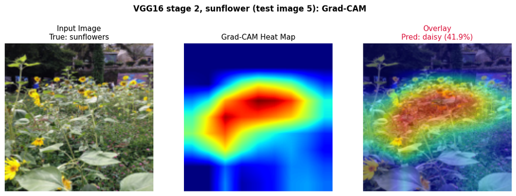

```python
# ============================================================
# Grad-CAM on the Problem 3 stage 2 model
# ============================================================

for layer in conv_base:                                     # VGG16's ReLUs overwrite their input in place,
    if isinstance(layer, nn.ReLU):                          # which the backward hook does not allow,
        layer.inplace = False                               # so make them return a new tensor (same results).

target_layer = conv_base[28]                                # Single target layer: last conv layer (block 5, conv 3).
print('Target layer:', target_layer)                        # Show it.

CAM_INDEX = 0                                               # Which test image to inspect.

image, true_label = test_data[CAM_INDEX]                    # Normalized image tensor and its true class.

print("Grad-CAM true class:", class_names[int(true_label)]) # Show the true class.

# 1. First test image.
show_gradcam(
    model=model,                                            # Problem 3 stage 2 model.
    target_layer=target_layer,                              # conv_base[28].
    image=image,                                            # The flower.
    true_label=true_label,                                  # Its true class.
    model_name=f"VGG16 stage 2, test image {CAM_INDEX}",    # Figure title.
)

# 2. The sunflower that Problem 3 misclassified (first sunflower in the test set).
sunflower_class = class_names.index('sunflowers')           # Label number of sunflowers (3).
sunflower_index = next(i for i, index in enumerate(test_indices)
                       if eval_view.targets[index] == sunflower_class)  # Position of the first sunflower in test_data.
image, true_label = test_data[sunflower_index]              # That image and its true class.

show_gradcam(
    model=model,                                            # Problem 3 stage 2 model.
    target_layer=target_layer,                              # conv_base[28].
    image=image,                                            # The sunflower.
    true_label=true_label,                                  # Its true class.
    model_name=f"VGG16 stage 2, sunflower (test image {sunflower_index})",  # Figure title.
)
```

## 11. Report on results

**Model check:** the recreated stage 2 model reached **90.38% test accuracy, the same as Problem 3**, so the heat maps explain the Problem 3 model.

**What Grad-CAM shows:** bright (red/yellow) regions are where the target layer `conv_base[28]` (VGG16's last convolutional layer) most strongly supported the predicted class; blue regions contributed little. Bright regions show relatively stronger model evidence, not proof that the model "understands" the flower.

| Image | True class | Predicted (confidence) | Where the heat map is strongest |
| --- | --- | --- | --- |
| Test image 0 | roses | **roses (99.9%)** ✅ | On the rose blooms in the centre-right of the bouquet |
| Sunflower (test image 5) | sunflowers | **daisy (41.9%)** ❌ | On a wide band of small, distant flowers and pale leaves in the middle of the field |

### Test image 0: correct prediction

- The heat map sits **on the roses themselves** (the red and pink rose heads to the right of centre), not on the black background.
- The other flowers in the bouquet (the pink lily-like flowers at the top left) get almost no weight, so the model separated the roses from the other flowers.
- Not every rose is highlighted: Grad-CAM shows the region that mattered **most**, and one cluster of roses was enough for a 99.9% prediction.

### Sunflower: wrong prediction

- The model focused on the **middle of the field**: many small, far-away yellow flowers mixed with light-coloured leaves.
- At this size the sunflowers look like **small yellow-centred flowers scattered in greenery**, which is closer to how daisies often appear in the dataset.
- The clearest, largest sunflower (bottom-left corner, partly cut off) is **not** highlighted, so the model missed the best evidence for "sunflowers".
- The low confidence (41.9% daisy) shows the model was unsure; in Problem 3, sunflowers was a close second (37.9%).

### Conclusion

Grad-CAM shows that the fine-tuned VGG16 bases its correct predictions on the flowers themselves. Its mistake on the sunflower image comes from a hard photo, with small and distant flowers and the clearest sunflower at the edge, rather than from looking at the background. Grad-CAM is useful for checking *why* a model predicted a class, especially for errors.